# Data visualisation I

O Rodriguez de Rivera Ortega, PhD

Univerisity of Exeter

# Introduction

## Introduction I

- Data visualization is part art and part science. The challenge is to get the art right without getting the science wrong, and vice-versa.
- A data visualization first and foremost has to accurately convey the data.
- At the same time, a data visualization should be aesthetically pleasing. Good visual presentations tend to enhance the message of the visualization.

## Introduction II

To provide a simple visual guideline of which examples should be emulated and which should be avoided, I am labeling problematic figures as “ugly,” “bad,” or “wrong”:

- Ugly - A figure that has aesthetic problems but otherwise is clear and informative
- Bad - A figure that has problems related to perception; it may be unclear, confusing, overly complicated, or deceiving
- Wrong - A figure that has problems related to mathematics; it is objectively incorrect

## Introduction-Example

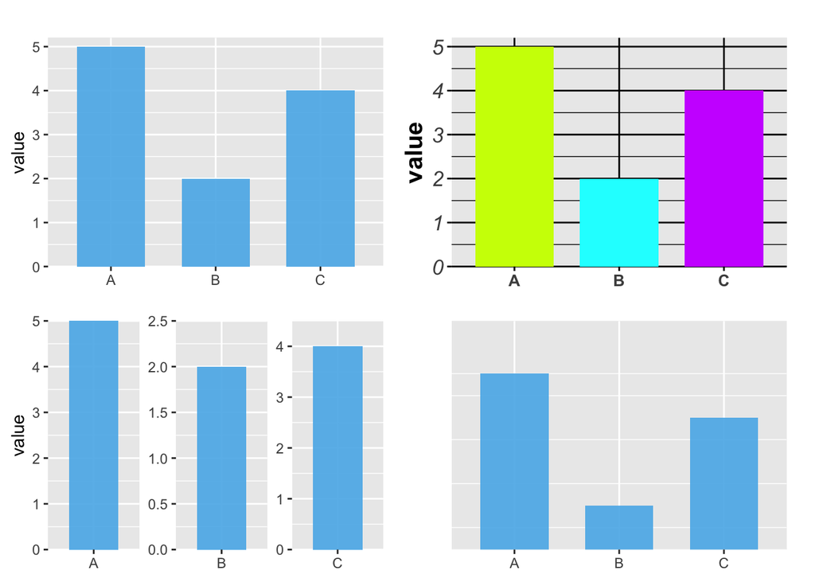

# Introduction to ggplot

## A simple example

- The functions in the ggplot2 package build up a graph in layers.
- We’ll build a a complex graph by starting with a simple graph and adding additional elements, one at a time. # #

We are going to download data from the III Forest Inventory (Murcia)

```r
##load data
library(curl)
FI_Murcia <- read.csv(curl("https://raw.githubusercontent.com/orrortega/statistics-natural-resources/main/data/FI_Murcia.csv"))
attach(FI_Murcia)
names(FI_Murcia)
```

```
## [1] "Species"   "Shape"     "Height"    "Diameter1" "Diameter2"
```

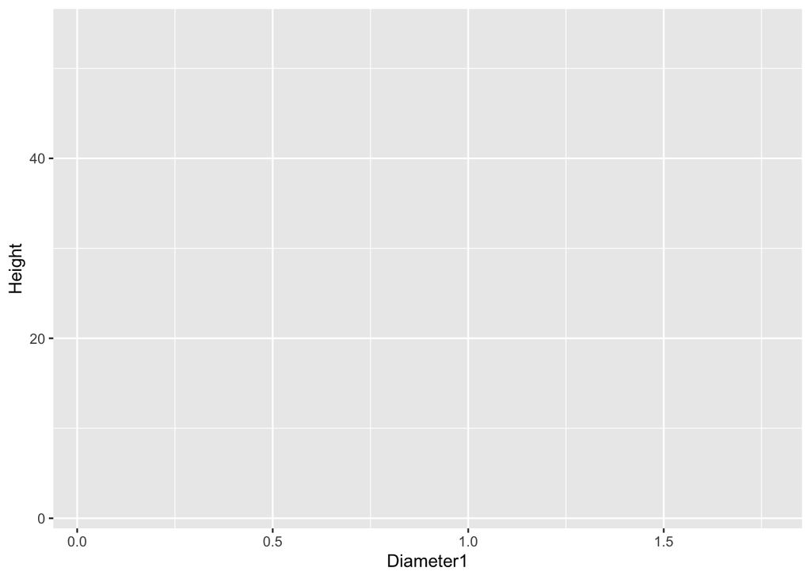

Map variables

```r
##specify dataset and mapping
library(ggplot2)
ggplot(data = FI_Murcia,
  mapping = aes(x = Diameter1, y = Height))
```

We need to specify what we wanted placed on the graph

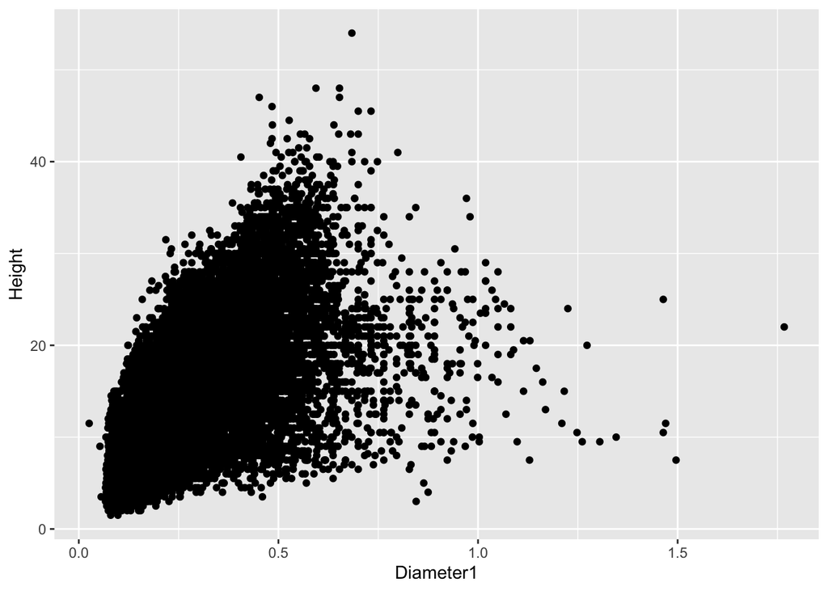

```r
##add geom_point
library(ggplot2)
ggplot(data = FI_Murcia,
  mapping = aes(x = Diameter1, y = Height))+
  geom_point()
```

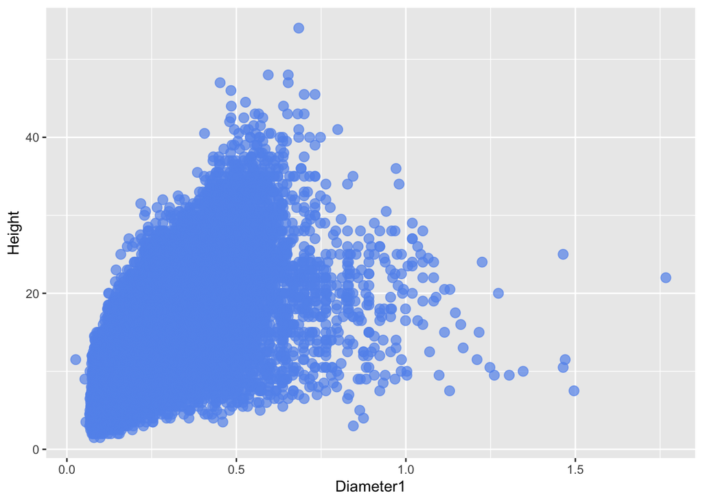

```r
##make points blue, larger, and semi-transparent
ggplot(data = FI_Murcia,
mapping = aes(x = Diameter1, y = Height)) +
  geom_point(color = "cornflowerblue", alpha = .7,
  size = 3)
```

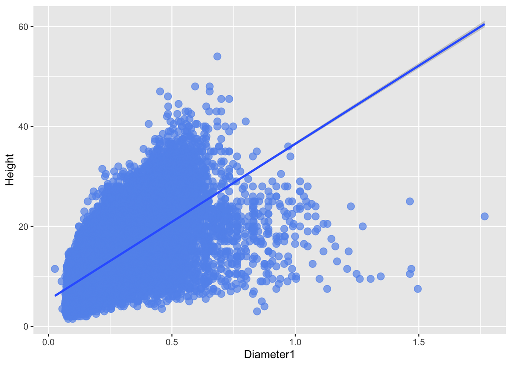

```r
##add a line of best fit
ggplot(data = FI_Murcia,
mapping = aes(x = Diameter1, y = Height)) +
  geom_point(color = "cornflowerblue", alpha = .7, size = 3) +
  geom_smooth(method = "lm")
```

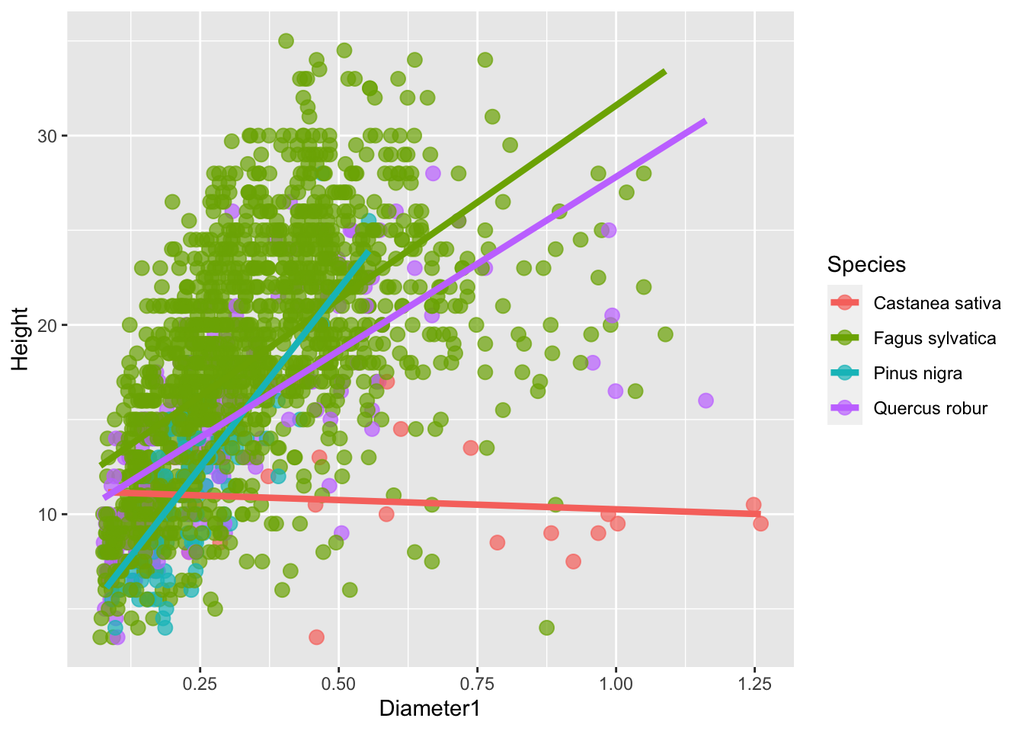

```r
##indicate species using color
FI_Murcia_sub = subset(FI_Murcia, Species == c("Castanea sativa", "Fagus sylvatica", "Pinus nigra", "Quercus robur"))
ggplot(data = FI_Murcia_sub,
mapping = aes(x = Diameter1, y = Height, color = Species)) +
  geom_point(alpha = .7, size = 3) +
  geom_smooth(method = "lm", se = FALSE, size = 1.5)
```

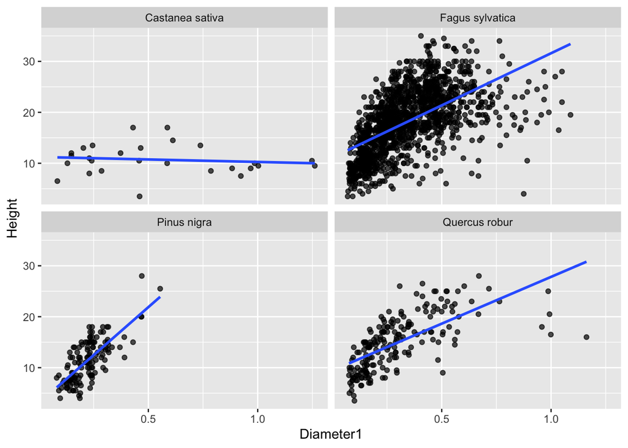

```r
# reproduce plot for each species
ggplot(data = FI_Murcia_sub,
mapping = aes(x = Diameter1, y = Height)) +
  geom_point(alpha = .7) +
  geom_smooth(method = "lm", se = FALSE) +
  scale_x_continuous(breaks = seq(0, 2, 0.5)) +
  scale_y_continuous(breaks = seq(0, 60, 10)) +
  scale_color_manual(values = c("indianred3","cornflowerblue")) +
  facet_wrap(~Species)
```